# data-viz

Scout Leonard

8/18/2021

## Get the lizards data

```r
lizards <- read_csv(here::here("data_tidy", "lizards.csv"))
```

## Make a histogram

Make a histogram of lizard weights.

If we want to fill in the graph: - **color** refers to points and lines - **fill** refers to the color of polygons - **size** changes the thickness of your lines - **linetype** defines the visualization of your lines

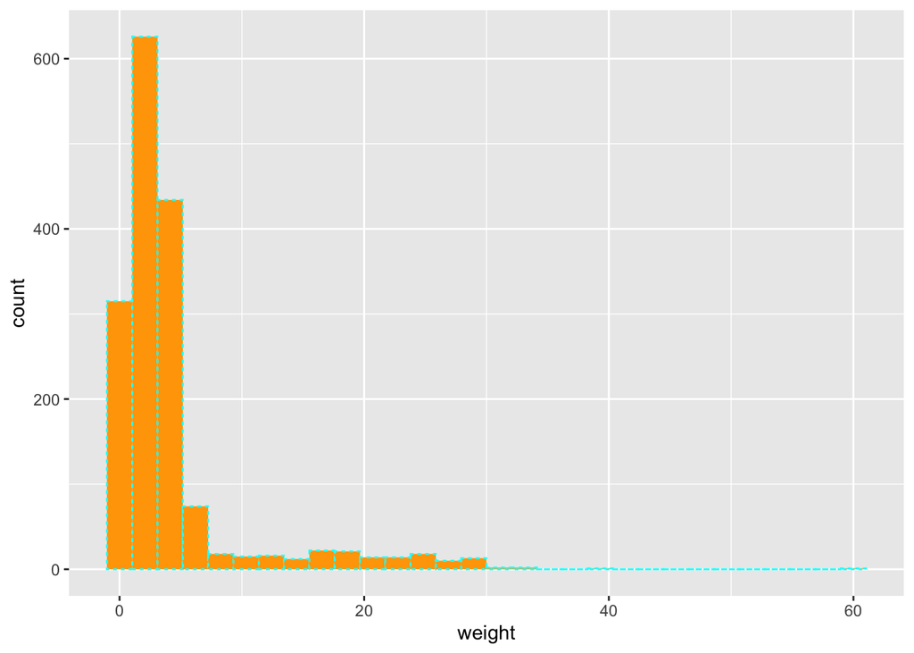

```r
ggplot(data = lizards, aes(x = weight)) +
  geom_histogram(fill = "orange",
                 color = "cyan",
                 size = 0.5,
                 linetype = "dotted")
```

## Point Plots

Make a point plot (scatterplot) with total length on x axis and weight on y axis. Shape (0-25)

*Different shape numbers, from 0 to 25, represent different point shapes.*

- **alpha** gives the opacity

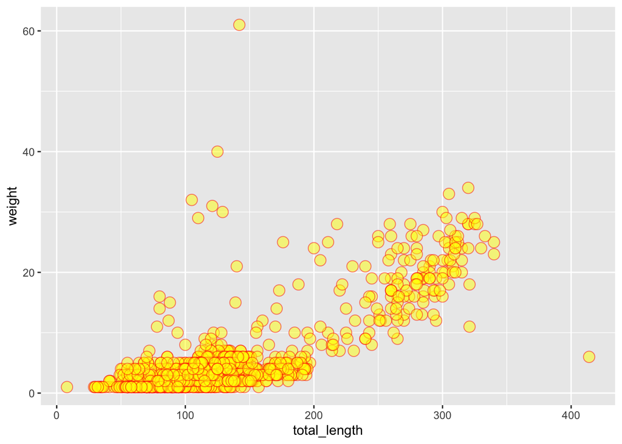

```r
ggplot(lizards, aes(x = total_length, y = weight)) +
  geom_point(shape = 21,
             fill = "yellow",
             color = "red",
             size = 4,
             alpha = 0.5)
```

## Bubble plot

Make a bubble plot where the color of the points varies based on common_name, and the size of points varies based in total_length.

DISCLAIMER: BAD IDEA

*when something changes based on a variable, it goes inside `aes()`. If something changes based on a constant, it goes outside `aes()`.

**There are a number of themes you can include in your graphs**

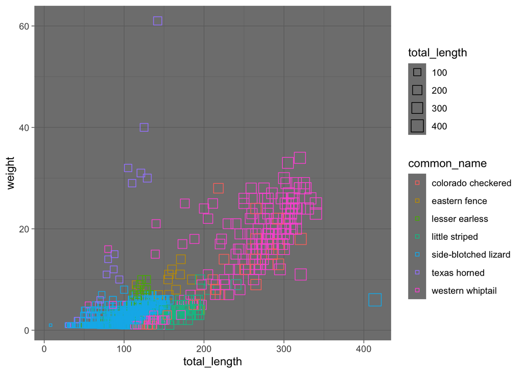

```r
ggplot(data = lizards, aes(x = total_length, y = weight)) +
  geom_point(aes(color = common_name, size = total_length),
             shape = 22) +
  theme_dark()
```

## Facet wraps

Helps people to see trends within groups. Groups the desired variable into groups.

You can choose the number of columns to help visualization.

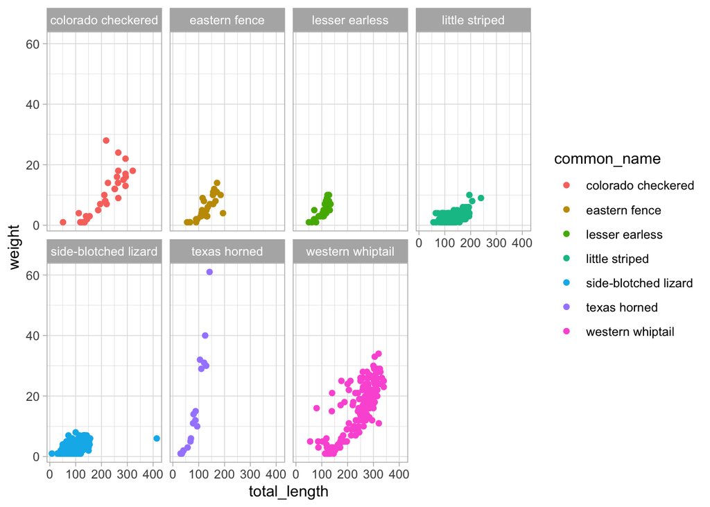

```r
ggplot(data = lizards, aes(x = total_length, y = weight)) +
  geom_point(aes(color = common_name)) +
  theme_light() +
  facet_wrap(~common_name, ncol = 4)
```

## Facet Grids

Creates grids based on the intersection of variables.

*Different levels of the sex variables in rows and tail variables in columns*

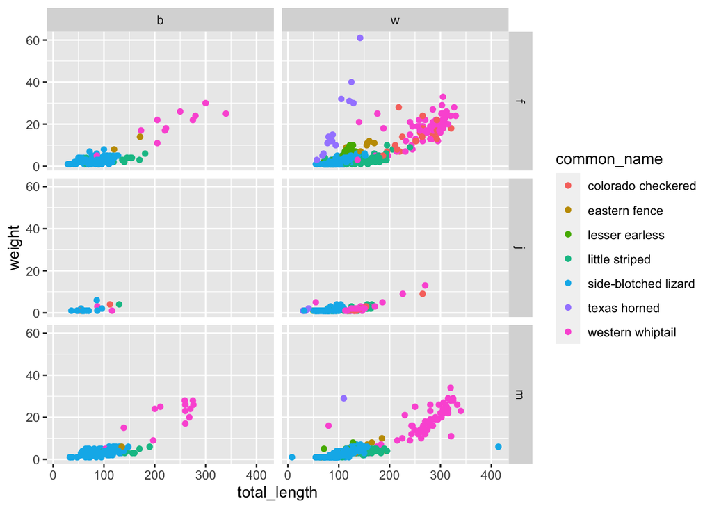

```r
ggplot(data = lizards, aes(x = total_length, y = weight)) +
  geom_point(aes(color = common_name)) +
  facet_grid(sex ~ tail)
```

```r
  theme_light()
```

[output not shown]

[output cut: 372 more lines]

[output not shown]

If you have a character, ggplot automattically arranges them alphabetically.

Find total lizard counts by different groups in common name.

```r
lizards_counts <- lizards %>%
  group_by(common_name) %>%
  summarize(count = n())

lizards_counts
```

```
## # A tibble: 7 × 2
##   common_name          count
##   <chr>                <int>
## 1 colorado checkered      31
## 2 eastern fence           29
## 3 lesser earless          37
## 4 little striped         160
## 5 side-blotched lizard  1176
## 6 texas horned            19
## 7 western whiptail       176
```

```r
#Same Thing
# lizards_counts <- lizards %>% dplyr::count(common_name)

#You can also use it to get the counts of two variables!
# lizard_counts_cn_tail <- lizards %>%  dplyr::count(common_name, tail)
```

To plot the total counts for lizards in this dataset:

*Put long categorical names in the y axis for space!*

Or use `coord_flip()`

The common names show up in alphabetical order. We can make common name a factor(instead of character), and assign the factor levels so they show up in a certain order. `fct_reorder()` makes the variable a factor. The “count” specification tells ggplot to reorder them by count in each variable!

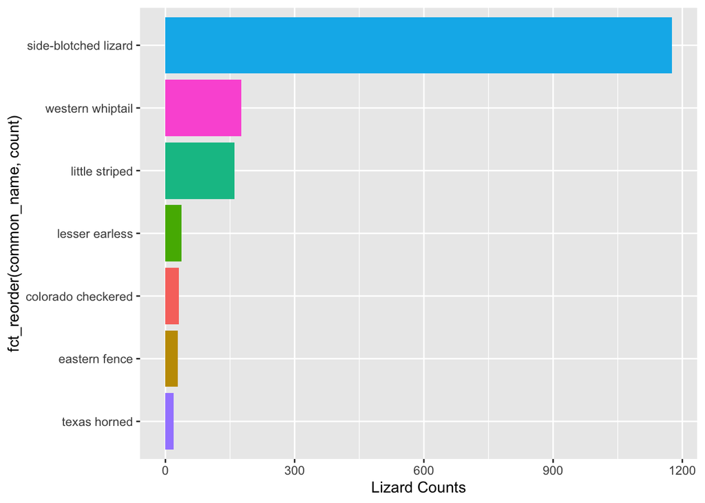

```r
ggplot(data = lizards_counts, aes(y = fct_reorder(common_name, count), x = count)) +
  geom_col(aes(fill = common_name), show.legend = FALSE) +
  labs(x = "Lizard Counts",
       )
```

Try converting common name to an ordered factor outside of ggplot, so that the factors are stored.

```r
lizards_counts <- lizards_counts %>%
  mutate(common_name = fct_reorder(common_name, count))

class(lizards_counts$common_name)
```

```
## [1] "factor"
```

```r
#SHows that the levels are no longer alphabetical
levels(lizards_counts$common_name)
```

```
## [1] "texas horned"         "eastern fence"        "colorado checkered"
## [4] "lesser earless"       "little striped"       "western whiptail"
## [7] "side-blotched lizard"
```

## Axis scale breaks, limits, and labels

Make a scatterplot of total_length versus weight.

- **Continuous variables**
  - breaks are the tick mark breaks
  - expands beyond your limits! but you can set expand to zero to eliminate that
    - When you see the outcome, you can see that removing the exmpansion can sometimes cut off points: sometimes it’s valuable!

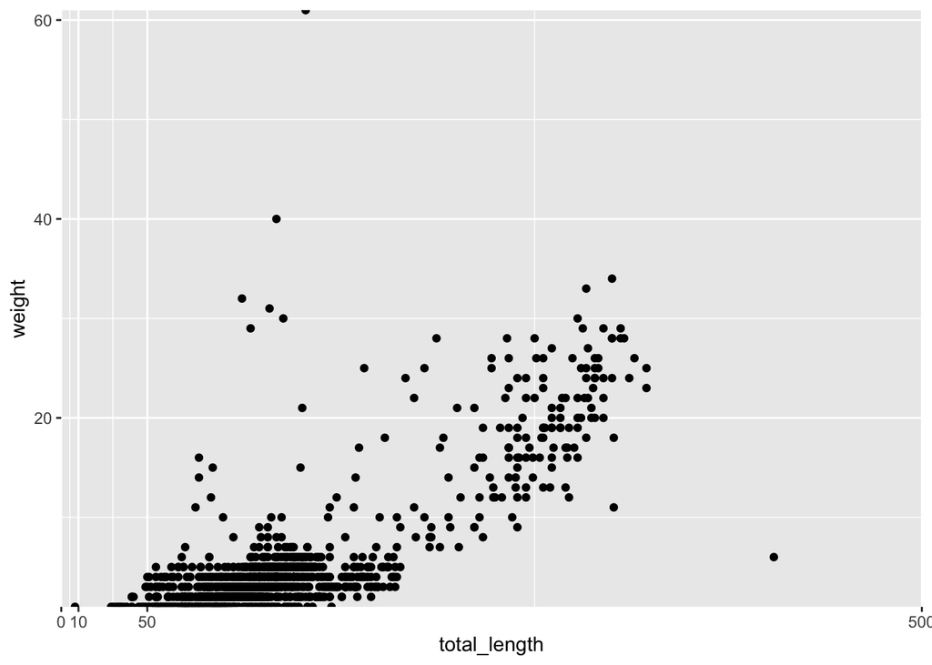

```r
ggplot(data = lizards, aes(x = total_length, y = weight)) +
  geom_point() +
  scale_x_continuous(breaks = c(0, 10, 50, 500),
                     limits = c(0, 500),
                     expand = c(0,0))+
  scale_y_continuous(expand = c(0,0))
```

Create a new version of lizards where lizards are counted by date. Transform date column to class Date, then find counts of observation by date.

```r
lizard_counts <- lizards %>%
  mutate(date = lubridate::mdy(date)) %>%
  count(date)
```

- **Date** Make a plot now that date has been converted to class date. Make a line plot (geom_line) of date (x) and count(y) Know what axes you are working on! Know what kind of data you are working with!

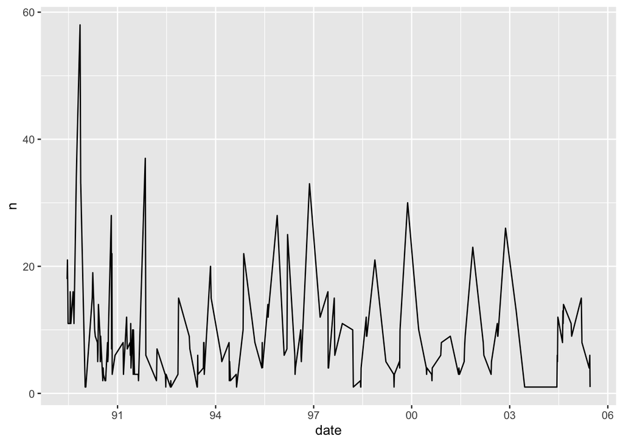

```r
ggplot(data = lizard_counts, aes(x = date, y = n)) +
  geom_line() +
  scale_x_date(date_breaks = "3 years",
               date_labels = ("%y"))
```

## Customized aesthetics with scale functions

- `scale_color_gradient()`
- `scale_color_gradientn()`: give a gradient of colors of your choice

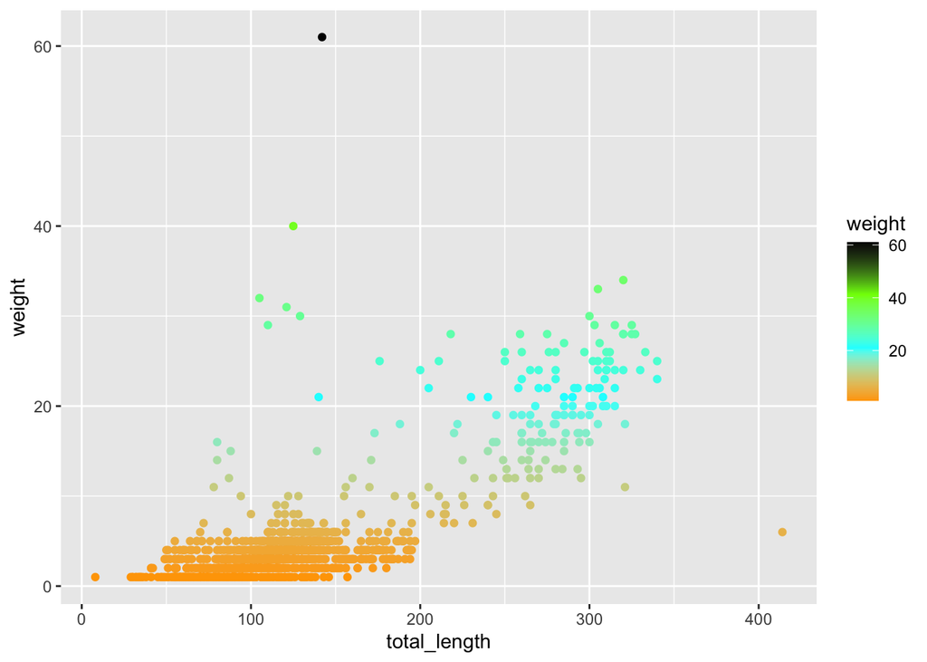

```r
ggplot(data = lizards, aes(x = total_length, y = weight)) +
  geom_point(aes(color = weight)) +
  scale_color_gradientn(colors = c("orange", "cyan", "chartreuse", "black"))
```

- you can define the gradient scale based on desired values, also! This creates a **binned color scale** using the function `scale_color_stepsn()` The number of breaks does not need to be the same as the number of colors

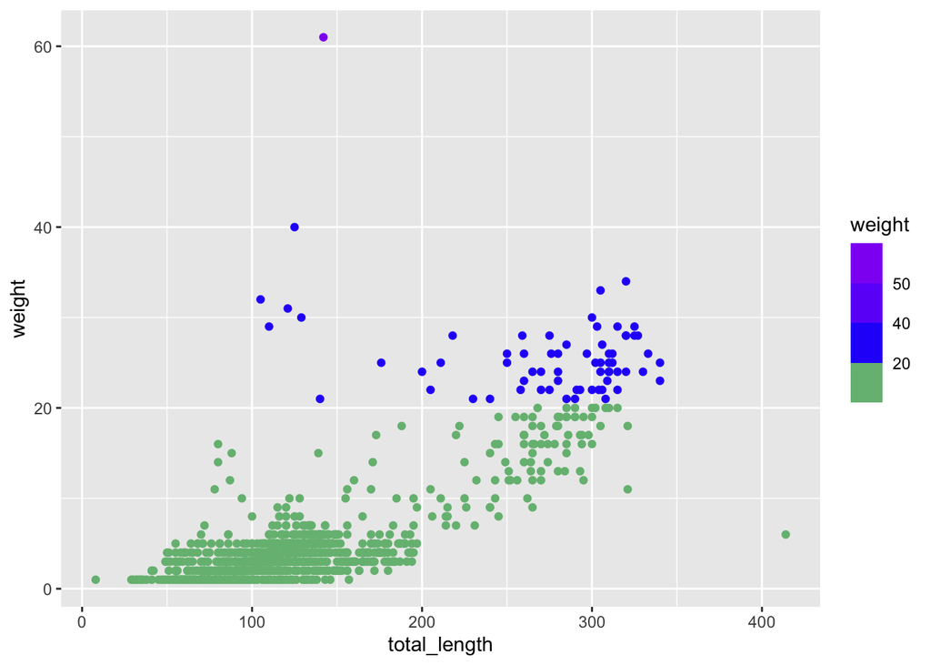

```r
ggplot(data = lizards, aes(x = total_length, y = weight)) +
  geom_point(aes(color = weight)) +
  scale_color_stepsn(colors = c("green", "blue", "purple"),
                     breaks = c(0, 20, 40, 50))
```

## Update a color scheme using a palette in paletteer

*Make a box plot with common name on the y-axis, and total_length on the x-axis, and color changing based on common_name.*

*Arranging order by median might make this more readable*

```r
#factor reorder to arrange by medians
#take the existing common name variable (a character) convert it to a factor, so it has levels, then reorder the factors based on a function (the median) using the total length of the lizards in the variable.
lizards_fct <- lizards %>%
  mutate(common_name = fct_reorder(common_name, total_length, .fun = median))

levels(lizards_fct$common_name)
```

```
## [1] "texas horned"         "side-blotched lizard" "lesser earless"
## [4] "eastern fence"        "little striped"       "colorado checkered"
## [7] "western whiptail"
```

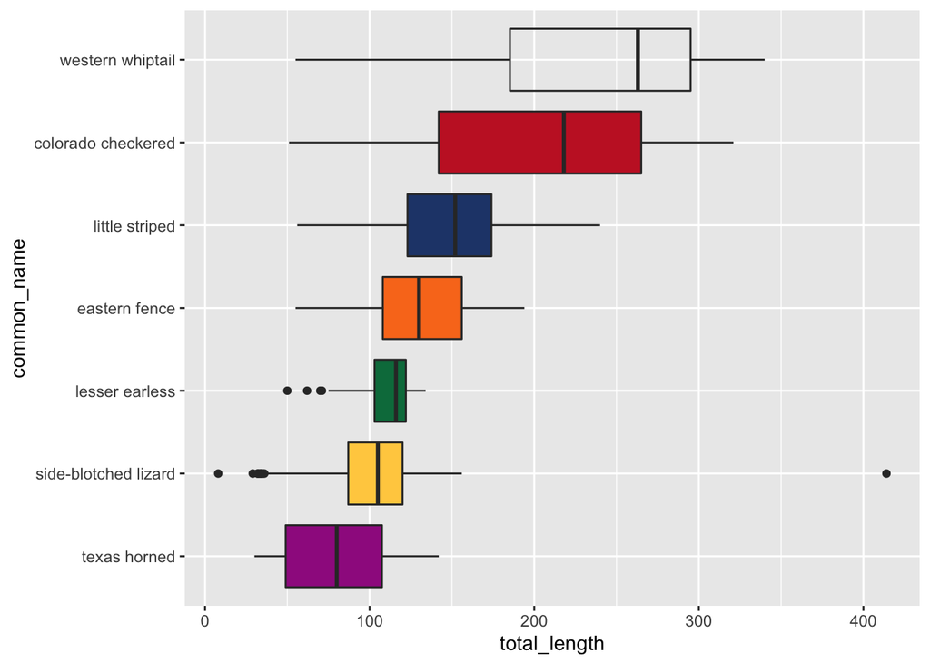

```r
ggplot(data = lizards_fct, aes(x = total_length, y = common_name)) +
  geom_boxplot(aes(fill = common_name), show.legend = FALSE) +
  scale_fill_paletteer_d(palette = "awtools::spalette")
```

## Theming

- what is the object stored that you want to change?
- what kind of element is it?
- what actual aesthetic is it you are changing?

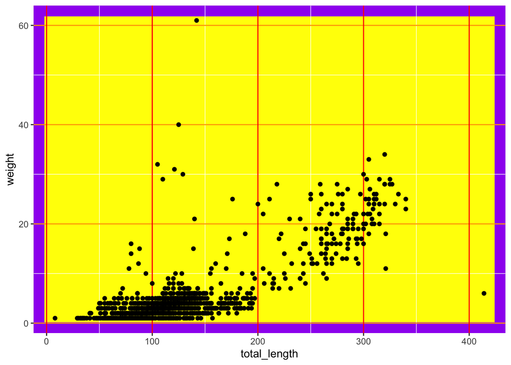

```r
ggplot(data = lizards, aes(x = total_length, y = weight)) +
  geom_point() +
  theme(
    panel.background = element_rect(fill = "yellow",
                                    color = "purple",
                                    size = 10),
    panel.grid.major.x = element_line(color = "red"),
    panel.grid.major = element_line(color = "blue"),
    panel.grid.major.y = element_line(color = "orange")
  )
```

```r
#panel.grid changes all gridlines
#panel.grid.major.x changes lines in the x direction
# most specific level is taken into account in themes, so x lines in red don't get overridden
```

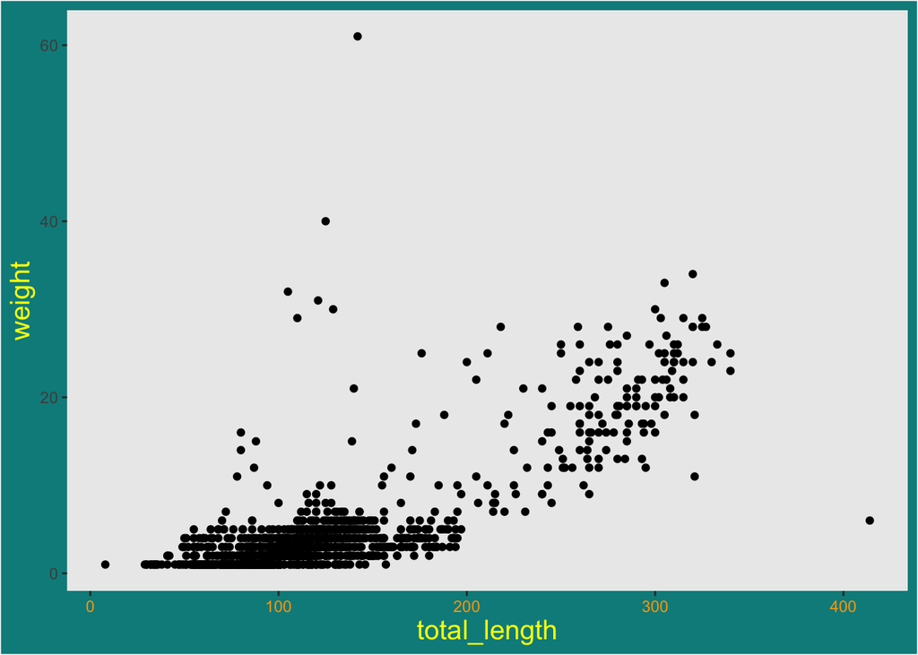

```r
#element_blank removed gridlines


ggplot(data = lizards, aes(x = total_length, y = weight)) +
  geom_point() +
  theme(
   panel.grid = element_blank(),
   plot.background = element_rect(fill = "cyan4"),
   axis.text.x = element_text(color = "orange"),
   axis.title = element_text(color = "yellow", size = 15)
  )
```